# Voter turnout model and recommendations

Joe Ciesielski

All code and data for this project can be found [here](https://github.com/jtcies/tmc-task).

## Background

Voters in a particular jurisdiction are being asked to consider a ballot measure that would restrict women’s access to healthcare. I was asked to use survey data to predict which respondents oppose the policy; these predictions will be used in voter turnout efforts.

Among survey respondents, 44.4% oppose the policy.

The chart below shows the coefficients of a logistic regression estimating opposition to the measure. This is a simple model not used to generate the final predictions but which can be helpful in understanding the influence of various factors on voters’ stances. Points on either extreme of the chart indicate that the predictor has a greater influence on support or opposition to the policy. Points close to zero indicate the predictor has relatively little influence on opposition.

By far, party is the largest predictor of support or opposition; party along with gender and conservative ideology are the only statistically significant factors.

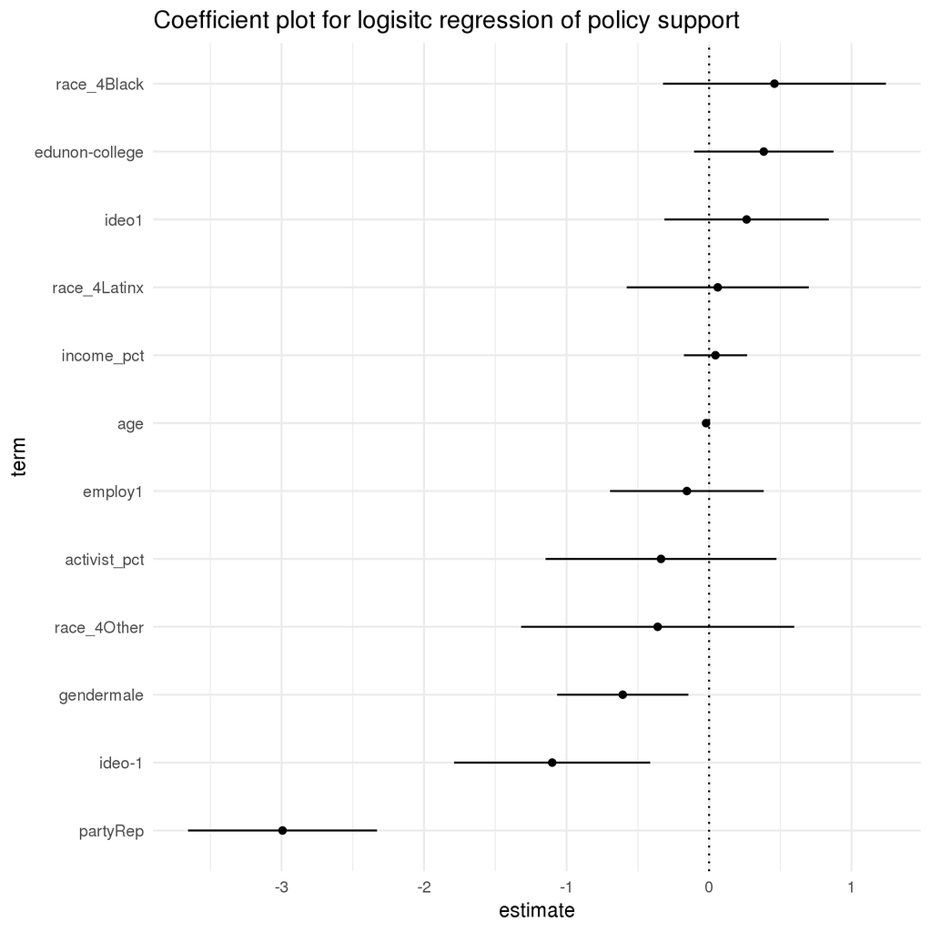

## Turnout recommendations

### Establishing a cutoff

The chart below shows how F1 changes with the cutoff on both the training data that was used to create the model and a validation dataset used to assess the quality of the predictions.

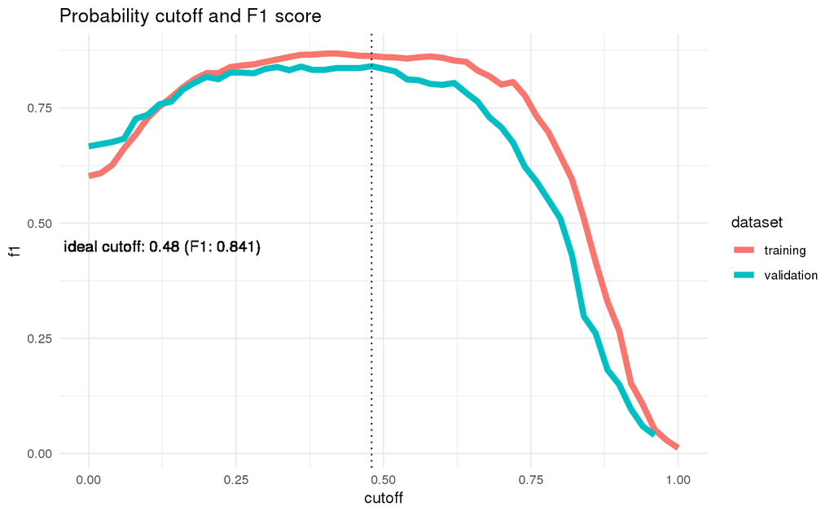

A cutoff 0.48 generates the highest F1 score on the validation data. However, based on the survey data, the ballot initiative may have more support than opposition in the jurisdiction. This may require setting a lower cutoff score to reach a greater number of people.

Using the cutoff of 0.48, 22.2% of voters in the validation data who supported the initiative were incorrectly identified as opposing while 88.8% of those that actually opposed the measure were correctly identified.

### Non-survey indicators for greater reach

It’s possible that organizers will want to target a larger group of individuals than just those for whom survey data is available. Because party is was the most influential predictor in determining opposition to the policy, I would recommend focusing on registered Democrats. The table below shows percent of registered Democrats who oppose the policy, broken down by race, education, and employment, indicators which may be available without the survey data. In these cases, white and Latino men, particularly college-educated white men, were the least likely to oppose the policy, but the policy receives relatively high levels of opposition among most women, and Black men.

Policy opposition by gender, educational attainment, employment, and race among Democrats

|  | White | Latinx | Black | Other |
| --- | --- | --- | --- | --- |
| female, college, employed | 93.3% (60) | 88.2% (17) | 81.2% (16) | 66.7% (9) |
| female, college, unemployed | 75.9% (58) | 72.2% (18) | 100% (3) | 83.3% (6) |
| female, non-college, employed | 75.0% (16) | 100% (4) | 66.7% (12) | 0% |
| female, non-college, unemployed | 82.9% (35) | 90.0% (10) | 60.0% (5) | 100% (2) |
| male, college, employed | 66.7% (27) | 65.0% (20) | 100% (9) | 25.0% (4) |
| male, college, unemployed | 66.7% (45) | 66.7% (3) | 88.9% (9) | 100% (1) |
| male, non-college, employed | 76.9% (13) | 50.0% (4) | 83.3% (6) | 100% (1) |
| male, non-college, unemployed | 77.8% (18) | 77.8% (9) | 90.0% (10) | 100% (2) |

Additionally, there appears to be a group of older, progressive Democrats who support the policy as shown in the chart below. It may be helpful to focus on younger voters who are more likely to oppose the ballot measure.

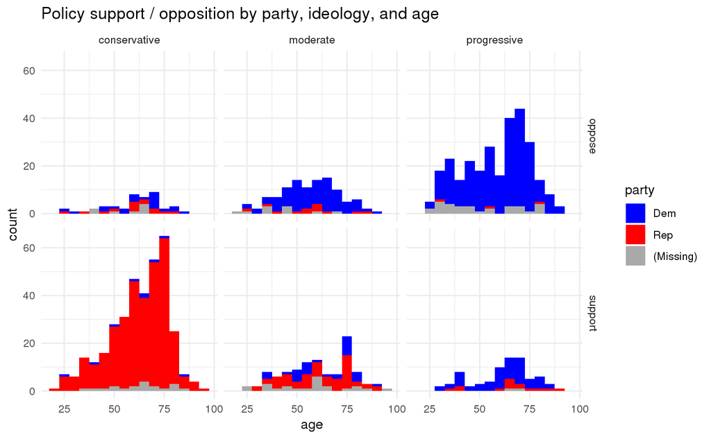